# 605-HW09-CLT-and-Generating-Functions

Michael Y.

October 27, 2019

# HW9 - Sums of RVs; Law of Large Numbers

## 1. #11 page 363

#### The price of one share of stock in the Pilsdorff Beer Company (see Exercise 8.2.12) is given by $Y_n$ on the $n^{th}$ day of the year.

#### Finn observes that the differences $X_n = Y_{n+1} - Y_n$ appear to be independent random variables with a common distribution having **mean** $\mu = 0$ and **variance** $\sigma^2 = \frac{1}{4}$ .

So, the first difference is $X_1 = Y_2 - Y_1$ .  
Thus, the price at time $Y_2 = X_1+Y_1= X_1+100$ .  
The next difference is $X_2 = Y_3 - Y_2$ .  
Likewise, the price at time $Y_3 = X_2+Y_2 = X_2 + X_1 + Y_1= X_2 + X_1 + 100$ .

Continuing, the price at time $Y_{j+1} = X_j + X_{j-1} + X_{j-2} + ... + X_1 + Y_1 = Y_1 + \sum\limits_{i=1}^j X_i=100+ \sum\limits_{i=1}^j X_i$ , and

the price at $Y_{n+1} = X_n + X_{n-1} + X_{n-2} + ... + X_1 + Y_1 = Y_1 + \sum\limits_{i=1}^n X_i=100+\sum\limits_{i=1}^n X_i$ .  
This can also be written as $Y_{n+1} -Y_1 = Y_{n+1}-100=\sum\limits_{i=1}^n X_i$ .

Because the average of the $X_j$ is $E[X] = \mu_{X} = 0$, the expected value of the $Y_j$ is $E[Y]=100+E[X]=100$ .

Although we do not know what kind of distribution is follwed by the individual daily price moves $X_i$ ,  
the Central Limit Theorem tells us that the standard deviation of the difference between their average $\frac{1}{n}\sum\limits_{i=1}^n X_i$ and its limit (here, $\mu_X = 0$) is distributed as $N(0,\frac{\sigma^2}{n})$ .

This can also be written as $Y_{n+1} = Y_1+\sum\limits_{i=1}^n X_i \sim N(Y_1,\sigma^2 n) \sim N\left(100, \frac{n}{4} \right)$ .

Here, $Y_{365} \sim N \left( 100,\frac{364}{4} \right)=N(100,91)$ .

When using the R function $pnorm$ we have to pass in the standard deviation rather than the variance, so below we use $\sqrt{91}$:

#### If $Y_1 = 100$, estimate the probability that $Y_{365}$ is:

### (a) $\ge 100$.

```r
probge100 = pnorm(100, mean=100, sd=sqrt(91),lower.tail=F)
probge100
```

```
## [1] 0.5
```

$Pr(Y_{365} \ge 100) = 0.5$ .

### (b) $\ge 110$.

```r
probge110 = pnorm(110, mean=100, sd=sqrt(91),lower.tail=F)
probge110
```

```
## [1] 0.147254
```

$Pr(Y_{365} \ge 110) = 0.147254$ .

### (c) $\ge 120$.

```r
probge120 = pnorm(120, mean=100, sd=sqrt(91),lower.tail=F)
probge120
```

```
## [1] 0.0180158
```

$Pr(Y_{365} \ge 120) = 0.018016$ .

### Simulation, to confirm theory

```r
nsims=1000000
Y365 = rep(NA,nsims)
Y1 = 100
sigma = 0.5
mu = 0
for(i in 1:nsims) {
  normrands=rnorm(364,mu,sigma)
  Y365[i]=Y1+sum(normrands)
}

p100=sum(Y365>=100)
p110=sum(Y365>=110)
p120=sum(Y365>=120)

count=c(p100,p110,p120)
simprob=count/nsims
theory=c(probge100,probge110,probge120)

diff=simprob-theory

result=cbind(cut=c(100,110,120),count,simprob,theory,diff)
result
```

```
##      cut  count  simprob    theory          diff
## [1,] 100 500389 0.500389 0.5000000  0.0003890000
## [2,] 110 147448 0.147448 0.1472537  0.0001943032
## [3,] 120  17920 0.017920 0.0180158 -0.0000958431
```

### Histogram

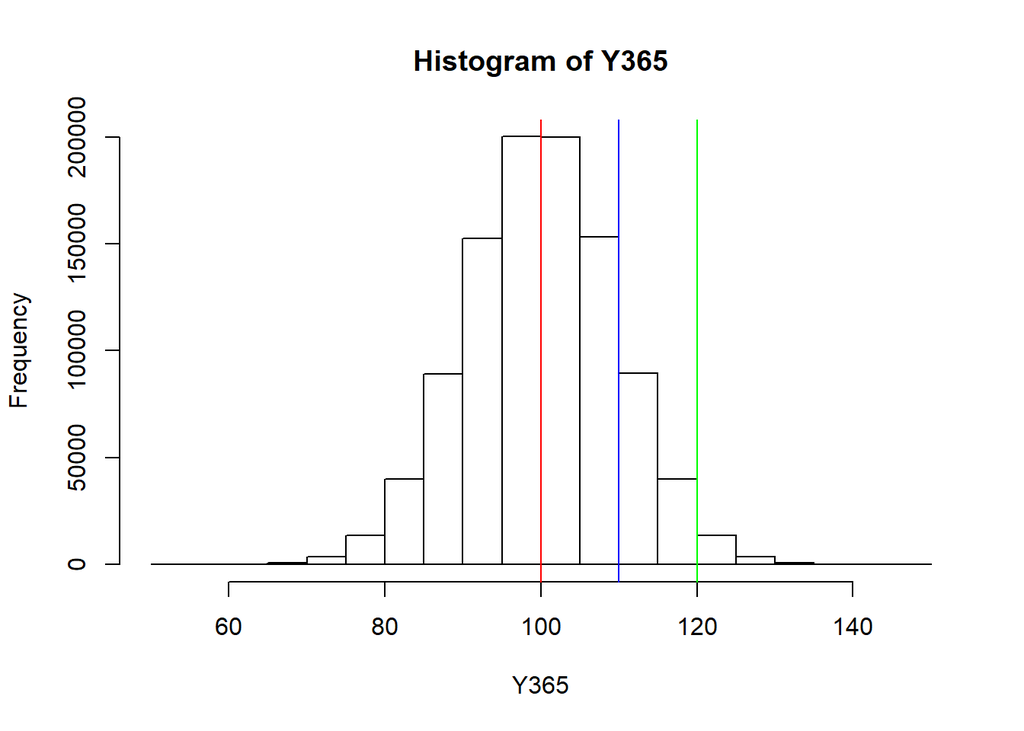

```r
hist(Y365,breaks=21)
abline(v=100,col="red")
abline(v=110,col="blue")
abline(v=120,col="green")
```

## 2. Calculate the expected value and variance of the *binomial* distribution using the moment generating function.

The moment-generating function is defined as $g(t) = E\left[e^{tX} \right] = \sum\limits_{j=1}^{\infty} e^{tx_j} p_{X}(j)$ .

For the binomial, $j \in \{0,1,2,...,n\}$ ; $x_j=j$; and $p_{X}(j) =\begin{pmatrix} n \\ j \end{pmatrix}p^{ j }(1-p)^{n-j}$ .

Then
$$\begin{aligned}g(t)
&= \sum\limits_{j=0}^{n} e^{tj}\begin{pmatrix} n \\ j \end{pmatrix}p^{ j }(1-p)^{n-j} \\
&= \sum\limits_{j=0}^{n} \begin{pmatrix} n \\ j \end{pmatrix}p^{ j }e^{tj}(1-p)^{n-j} \\
&= \sum\limits_{j=0}^{n} \begin{pmatrix} n \\ j \end{pmatrix} \left(pe^t \right)^{ j }(1-p)^{n-j} \\
&= \left(pe^t +(1-p)\right)^n
\end{aligned}$$

#### First derivative:

So, $g' = \frac{dg}{dt}= n \left(pe^t +(1-p)\right)^{n-1} pe^t$

and
$$\begin{aligned}
\mu_1
&=g'(t=0) \\
&= n \left(pe^0 +(1-p)\right)^{n-1} pe^0 \\
&= n \left( 1\right)^{n-1} p \\
&= np
\end{aligned}$$

### **Expected Value** = $\mu_1= np$

#### Second derivative:

$g'' = \frac{d^2g}{dt^2}= n(n-1) \left(pe^t +(1-p)\right)^{n-2} (pe^t)^2 + n \left(pe^t +(1-p)\right)^{n-1} pe^t$
$$\begin{aligned}
\mu_2=g''_{(t=0)}
&= n(n-1) \left(pe^0 +(1-p)\right)^{n-2} (pe^0)^2 + n \left(pe^0 +(1-p)\right)^{n-1} pe^0 \\
&= n(n-1) \left(p +(1-p)\right)^{n-2} p^2 + n \left(p +(1-p)\right)^{n-1} p \\
&= n(n-1) p^2 + n p \\
&= n^2 p^2 - np^2 +np
\end{aligned}$$

So,
$$\begin{aligned}
\sigma^2 &= \mu_2 - \mu_1^2 \\
&= n^2 p^2 - np^2 +np - n^2 p^2 \\
&= np - np^2 \\
&= np(1-p)
\end{aligned}$$

### **Variance** = $\sigma^2 = \mu_2 - \mu_1^2 = np(1-p)$

## 3. Calculate the expected value and variance of the *exponential* distribution using the moment generating function.

Here the moment-generating function is defined as $g(t) = E\left[e^{tX} \right] = \int\limits_{x=0}^{\infty} e^{tx} f_{X}(x) dx$ .

For the exponential, $X \in [0,\infty)$ and $f_{X}(x) = \lambda e^{-\lambda x}$ .

Then
$$\begin{aligned}g(t)
&= \int\limits_{x=0}^{\infty} e^{tx} \lambda e^{-\lambda x} dx \\
&= \int\limits_{x=0}^{\infty} \lambda e^{(t-\lambda) x} dx \\
&= \left. \frac{\lambda e^{(t-\lambda) x}}{(t-\lambda)} \right|_{x=0}^{x=\infty} \\
&= \frac{0-\lambda}{(t-\lambda)}, \quad for \quad t<\lambda \\
&= \frac{\lambda}{\lambda-t}, \quad for \quad t<\lambda \\
&= \lambda(\lambda-t)^{-1}, \quad for \quad t<\lambda
\end{aligned}$$

#### First derivative:

$$\begin{aligned}
g'(t)
&=\frac{dg}{dt} \\
&= -\lambda(\lambda-t)^{-2}(-1)\\
&=\lambda(\lambda-t)^{-2}\\
&=\frac{\lambda}{(\lambda-t)^2}
\end{aligned}$$

$$\begin{aligned}
\mu_1
&= g'(0) \\
&= \left.\frac{\lambda}{(\lambda-t)^2} \right|_{t=0} \\
&= \frac{\lambda}{\lambda^2} \\
&=\frac{1}{\lambda} \\
&= \lambda^{-1}
\end{aligned}$$

### **Expected value**: $\mu_1 = \frac{1}{\lambda}$

#### Second derivative:

$$\begin{aligned}
g''(t)
&=\frac{d^2g}{dt^2} \\
&= -2\lambda(\lambda-t)^{-3}(-1)\\
&=2\lambda(\lambda-t)^{-3}\\
&=\frac{2\lambda}{(\lambda-t)^3}
\end{aligned}$$

$$\begin{aligned}
\mu_2 &= g''(0) \\
&= \left.\frac{2\lambda}{(\lambda-t)^3} \right|_{t=0} \\
&= \frac{2\lambda}{\lambda^3} \\
&=\frac{2}{\lambda^2}
\end{aligned}$$

So,
$$\begin{aligned}
\sigma^2 &= \mu_2 - \mu_1^2 \\
&= \frac{2}{\lambda^2} - \frac{1}{\lambda^2} \\
&= \frac{1}{\lambda^2} \\
&= \lambda^{-2}
\end{aligned}$$

### **Variance** = $\sigma^2 = \mu_2 - \mu_1^2 = \frac{1}{\lambda^2}$